# ¶ Assignment 4: Data from elsewhere (Division and Power in the 1%) ¶

*Agenda*: Importing and manipulating data; writing functions to estimate parameters; writing functions to check model fit.

#### INSTRUCTIONS:

- Type each one of the R commands in this lesson on the space provided below.
- You can embed an R code chunk like this:

  ```r
  summary(cars)
  ```

  ```
  ##      speed           dist
  ##  Min.   : 4.0   Min.   :  2.00
  ##  1st Qu.:12.0   1st Qu.: 26.00
  ##  Median :15.0   Median : 36.00
  ##  Mean   :15.4   Mean   : 42.98
  ##  3rd Qu.:19.0   3rd Qu.: 56.00
  ##  Max.   :25.0   Max.   :120.00
  ```

- Before you move to the next step, highlight or move the cursor to the end of the individual R command and click on **Run**. Do this for all R commands.
- After you are done click the **Knit HTML**, **Knit PDF** button (upper left window). A document will be generated that includes both content as well as the output of any embedded R code chunks within the document.
- Go to File –> Save. Name your file.
- Upload the file to the Moodle site by using the link provided.

We continue to look at the very rich by turning to a more systematic data source than Forbes magazine, the World Top Incomes Database hosted by the Paris School of Economics [http://topincomes.g-mond.parisschoolofeconomics.eu]. This is derived from income tax reports, and compiles information about the very highest incomes in various countries over time, trying as hard as possible to produce numbers that are comparable across time and space. For most countries in most time periods, the upper end of the income distribution roughly follows a Pareto distribution, with probability density function

$$f(x)=\frac{(a-1)x^{-a}}{x_{min}^{1-a}}$$

for incomes x ≥ x_{min}. (Typically, xmin is large enough that only the richest 3–4% of the population falls above it.) As the Pareto exponent a gets smaller, the distribution of income becomes more unequal, that is, more of the population’s total income is concentrated among the very richest people.

##### Problem 1. (10 points)

Open the file and make a new variable containing only the year, “P99”, “P99.5” and “P99.9”” variables; these are the income levels which put one at the 99th, 99.5th, and 99.9th, percentile of income. What was P99 in 1972? P99.5 in 1942? P99.9 in 1922? You must identify these using your code rather than looking up the values manually. (You may want to modify the column names to make some of them shorter.)

##### Solution

Type your answer here

```r
data = read.csv("wtid-report.csv")
P99 = data[data$Year == 1972, "P99.income.threshold"]
P99
```

```
## [1] 209076.6
```

```r
P99.5 = data[data$Year == 1942, "P99.5.income.threshold"]
P99.5
```

```
## [1] 183217
```

```r
P99.9 = data[data$Year == 1922, "P99.9.income.threshold"]
P99.9
```

```
## [1] 400214.2
```

##### Problem 2. (10 points)

Plot the three percentile levels against time. Make sure the axes are labeled appropriately, and in particular that the horizontal axis is labeled with years between 1913 and 2012, not just numbers from 1 to 100.

##### Solution

Type your answer here

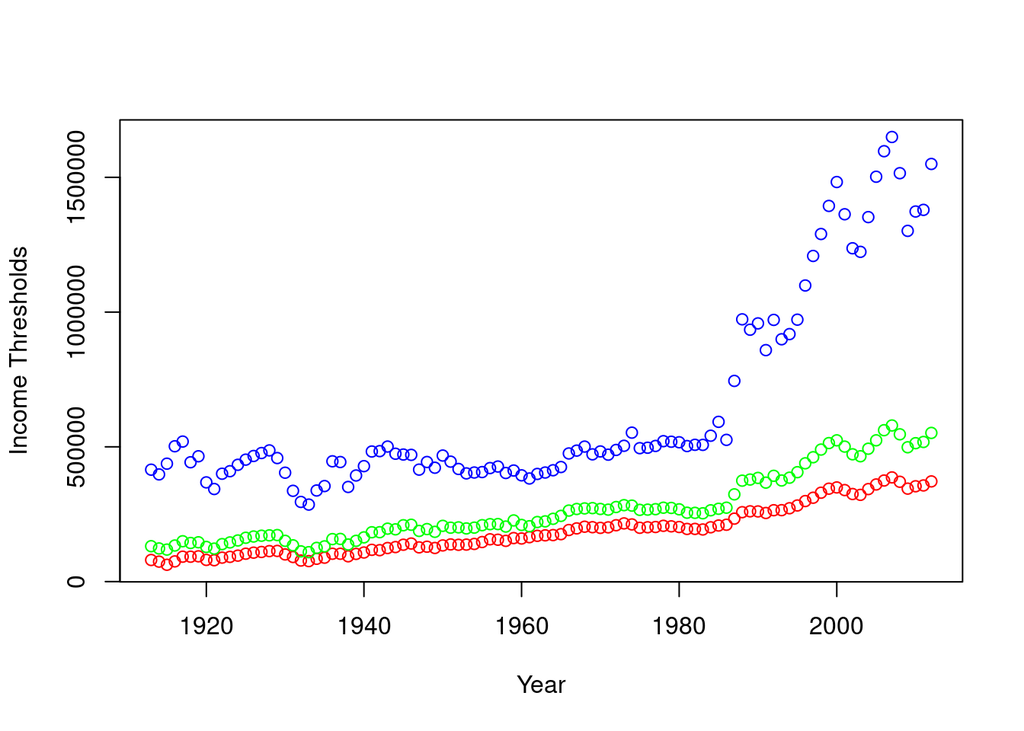

```r
plot(data$Year, data$P99.income.threshold, col = "red", ylab = "Income Thresholds", xlab = "Year", ylim = range(data$P99.income.threshold, data$P99.5.income.threshold, data$P99.9.income.threshold))
points(data$Year, data$P99.5.income.threshold, col = "green")
points(data$Year, data$P99.9.income.threshold, col = "blue")
```

##### Problem 3. (10 points)

One can show from the earlier equations that one can estimate the exponent by the formula

$$a = 1 - \frac{log 10}{log P99/P 99.9}$$

Write a function, exponent.est_ratio() which takes in values for P99 and P99.9, and returns the value of a implied by the above equation. Check that if P99=1e6 and P99.9=1e7, your function returns an a of 2.

##### Solution

Type your answer here

```r
exponent.est = function(P99, P99.9){
  a = 1 - ((log(10)/(log(P99/P99.9))))
  return(a)
}
exponent.est(1e6, 1e7)
```

```
## [1] 2
```

# Part II

##### Problem 4. (10 points)

Estimate a for each year in the data set, using your exponent.est_ratio() function. If the function was written properly, you should not need to use a loop. Plot your estimate of a over time. Do the results look reasonable? (Remember that smaller exponents mean more income inequality.)

##### Solution

Type your answer here

```r
(exponent.est(data$P99.income.threshold, data$P99.9.income.threshold)->a)
```

```
##   [1] 2.399194 2.369454 2.182215 2.209948 2.332909 2.467761 2.437956 2.514182
##   [9] 2.570057 2.528930 2.538132 2.531042 2.559757 2.568699 2.567713 2.577208
##  [17] 2.652442 2.657431 2.763211 2.729402 2.737955 2.662040 2.661589 2.572885
##  [25] 2.579406 2.744686 2.713150 2.670078 2.632861 2.616993 2.653235 2.758099
##  [33] 2.860191 2.914019 2.942128 2.868629 2.886756 2.843344 2.965486 3.057691
##  [41] 3.144066 3.163787 3.260079 3.331097 3.276828 3.347559 3.455955 3.549642
##  [49] 3.732302 3.691356 3.683629 3.636980 3.609517 3.529493 3.554904 3.557833
##  [57] 3.708645 3.601233 3.708177 3.713821 3.716491 3.404756 3.534538 3.552653
##  [65] 3.529190 3.493215 3.478263 3.455949 3.434579 3.412635 3.386331 3.329801
##  [73] 3.198499 3.519991 2.986043 2.731961 2.803516 2.767106 2.893031 2.772028
##  [81] 2.884516 2.893022 2.863182 2.767954 2.697085 2.688395 2.648073 2.592855
##  [89] 2.656636 2.722590 2.724004 2.679128 2.612694 2.589172 2.586832 2.634218
##  [97] 2.734064 2.697256 2.702601 2.612788
```

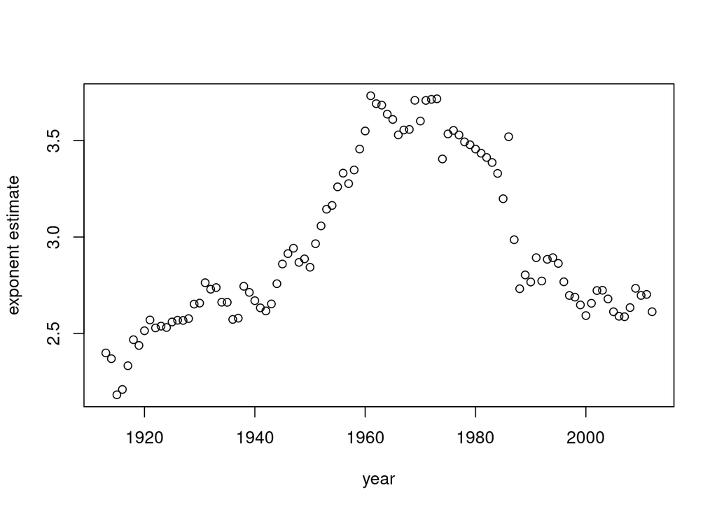

```r
plot(data$Year, a, ylab = "exponent estimate", xlab = "year")
```

```r
"yes the results look reasanable"
```

```
## [1] "yes the results look reasanable"
```

##### Problem 5. (10 points)

There were 160,681 households in the top 0.1% in the US in 2012. Using your estimated value of a for 2012, calculate approximately how many households had an income of over $50 million.

##### Solution

Type your answer here

```r
x = ((50000000)^(1-a[100]))/(1549616)^(1-a[100])
x*160681
```

```
## [1] 592.4853
```

##### Problem 6. (10 points)

The logic leading the equation above also implies that

$$(P99.5/P99.9)^{1-a}=5$$

Write a function which takes P99.5, P99.9 and a, and calculates the left-hand side of that equation. Plot the values for each year, using the data and your estimates of the exponent. Add a horizontal line with vertical coordinate 5. How good is the fit?

##### Solution

Type your answer here

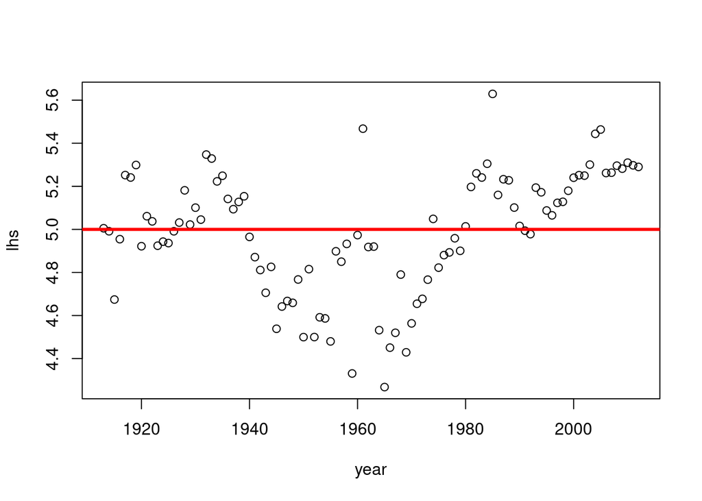

```r
left = function(P99.5, P99.9, a){
  (P99.5/P99.9)^(1-a)
}
plot(data$Year, left(data$P99.5.income.threshold, data$P99.9.income.threshold, a), ylab = "lhs", xlab = "year")
abline(h = 5, col = "red",lwd = 3)
```

##### Problem 7. (10 points)

By parallel reasoning, we should have
$$(P90/P95)^{1-a}=2$$
. Repeat the previous step with this formula. How would you describe this fit compared to the previous ones? (Note: the formula
$$a = 1 -
\frac{log 10}{log P99/P 99.9}$$
is not the best way to estimate a, but it is one of the simplest.)

##### Solution

Type your answer here

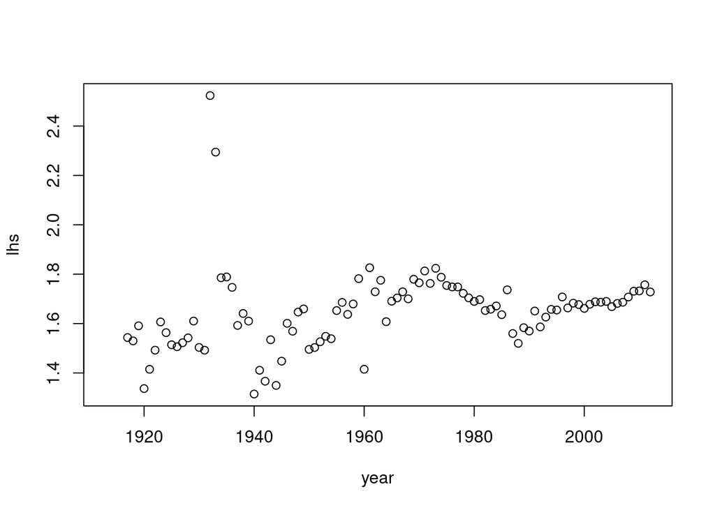

```r
leftr = function(P90, P95, a){
  (P90/P95)^(1-a)
}
plot(data$Year, leftr(data$P90.income.threshold, data$P95.income.threshold, a), ylab = "lhs", xlab = "year")
```

“the second graph is more tightly together at a lower y value and has a couple outliers going higher on the y axis”